# Тестовое задание

Вам предлагается проанализировать датасет (CSV-файл) с данными о визитах в спа-салоны.  
Датасет содержит следующие колонки:

`id` — id визита;  
`Дата и время` — Дата и время визита;  
`Салон` — номер салона;  
`Клиент` — идентификатор клиента;  
`Количество часов` — продолжительность услуги;  
`Способ оплаты` - Как был оплачен визит - наличными или платежным документом;  
`Вид платежного документа` — например, Сертификат или Абонемент;  
`Дата первого визита` - Дата первого визита данного клиента.

**Задачи:**

**Очистка данных:**  
Проверьте данные на наличие пропущенных значений, дубликатов и аномалий. Преобразуйте данные для работы. Опишите, какие преобразования вы провели и зачем?

**Анализ данных:**  
● Определите среднюю продолжительность услуг  
● Определите количество уникальных клиентов  
● Определите количество новых клиентов  
● Определите среднюю частоту и продолжительность визита

**Визуализация:**  
Постройте графики этих показателей по месяцам

**Интерпретация:**  
Сформулируйте 3 вывода на основе анализа данных.

## Общая информация.

```python
# Импорт стандартных библиотек
import warnings

# Импорт сторонних библиотек
import pandas as pd
import numpy as np
import matplotlib.pyplot as plt
import seaborn as sns

# Отключение предупреждений
pd.options.mode.chained_assignment = None
warnings.filterwarnings('ignore')
```

### Считываем данные из CSV-файла в датафрейм и сохраняем в переменную df.

```python
df = pd.read_csv('visits_test2.csv')
```

### Выводим случайные 10 строк таблицы на экран.

```python
df.sample(10)
```

|  | id | Дата и время | Вид товара | Количество часов | Вид платежного документа | Дата первого визита | Способ оплаты | Клиент | Салон |
| --- | --- | --- | --- | --- | --- | --- | --- | --- | --- |
| 79 | 1291840998937992086 | 2023-01-02 13:50:34 | Услуга | 1 | Абонемент сетевой | 2022-06-12 15:38:43 | Платежный документ | MZNF61983918472827 | ZZXU06573228044615 |
| 22217 | 1291894507891801281 | 2023-03-05 00:12:09 | Услуга | 1 | Сертификат сетевой | 2023-01-26 18:14:09 | Платежный документ | VPHL30984806174940 | QLZG01986879029921 |
| 111048 | 1292116726968557454 | 2023-11-17 16:57:25 | Услуга | 0,5 | Абонемент сетевой | 2021-01-31 13:39:00 | Платежный документ | HPLU98487258246742 | VSUK56847009380208 |
| 54760 | 1291968957448347020 | 2023-05-30 16:14:45 | Услуга | 1 | Сертификат сетевой | 2015-10-16 14:47:44 | Платежный документ | SCWS06547827323184 | RBWR33495280308770 |
| 84030 | 1292045816603608987 | 2023-08-27 15:13:22 | Услуга | 0,282 | Сертификат сетевой | 2023-08-11 15:35:06 | Платежный документ | YBSU59067414377472 | FBGE10141738874303 |
| 92100 | 1292068167205047527 | 2023-09-22 00:04:27 | Услуга | 1 | Абонемент сетевой | 2022-07-15 00:44:21 | Платежный документ | QWMI34512334296154 | EJID63912988089507 |
| 55581 | 1291970860648168671 | 2023-06-01 21:06:45 | Услуга | 1 | Абонемент сетевой | 2023-06-01 21:06:45 | Платежный документ | PERG64229035700086 | ZOVC60745621520960 |
| 75620 | 1292023580957839111 | 2023-08-01 21:33:56 | Услуга | 0,5 | NaN | 2019-05-30 19:15:30 | Нал/Безнал | LQPW70734800448232 | NXTS65623173703673 |
| 72968 | 1292016385593589241 | 2023-07-24 13:41:39 | Услуга | 0,5 | Абонемент сетевой | 2016-12-18 17:06:10 | Платежный документ | PZFX23450654351380 | TZUI24086436814234 |
| 116442 | 1292131254909560241 | 2023-12-04 00:30:31 | Услуга | 0,022 | Сертификат сетевой | 2017-03-08 22:08:08 | Платежный документ | VCIT74282032228752 | QLZG01986879029921 |

### Выводим основную информацию о датафрейме с помощью метода info().

```python
df.info()
```

```
<class 'pandas.core.frame.DataFrame'>
RangeIndex: 125101 entries, 0 to 125100
Data columns (total 9 columns):
 #   Column                    Non-Null Count   Dtype
---  ------                    --------------   -----
 0   id                        125101 non-null  int64
 1   Дата и время              125101 non-null  object
 2   Вид товара                125101 non-null  object
 3   Количество часов          125101 non-null  object
 4   Вид платежного документа  81461 non-null   object
 5   Дата первого визита       125101 non-null  object
 6   Способ оплаты             125101 non-null  object
 7   Клиент                    125101 non-null  object
 8   Салон                     125101 non-null  object
dtypes: int64(1), object(8)
memory usage: 8.6+ MB
```

**Замечание:** С помощью этой команды видны тип данных таблицы, а также количество записей без пропусков.

## Преобразование и очистка данных.

### Преобразуем типы данных.

```python
# Преобразование столбцов в формат даты
df['Дата и время'] = pd.to_datetime(df['Дата и время'], format='%Y-%m-%d %H:%M:%S')
df['Дата первого визита'] = pd.to_datetime(df['Дата первого визита'], format='%Y-%m-%d %H:%M:%S')
# Преобразование столбца в формат числа с дробного числа
df['Количество часов'] = df['Количество часов'].str.replace(',','.').astype(float)
df.info()
```

```
<class 'pandas.core.frame.DataFrame'>
RangeIndex: 125101 entries, 0 to 125100
Data columns (total 9 columns):
 #   Column                    Non-Null Count   Dtype
---  ------                    --------------   -----
 0   id                        125101 non-null  int64
 1   Дата и время              125101 non-null  datetime64[ns]
 2   Вид товара                125101 non-null  object
 3   Количество часов          125101 non-null  float64
 4   Вид платежного документа  81461 non-null   object
 5   Дата первого визита       125101 non-null  datetime64[ns]
 6   Способ оплаты             125101 non-null  object
 7   Клиент                    125101 non-null  object
 8   Салон                     125101 non-null  object
dtypes: datetime64[ns](2), float64(1), int64(1), object(5)
memory usage: 8.6+ MB
```

### Проверим датафрейм на наличие явных дубликатов.

```python
# Поиск дубликатов
df.duplicated().sum()
```

```
1009
```

**Замечание:** Нашлось 1009 дублирующих записей.

```python
# Удаление дубликатов
df = df.drop_duplicates()
```

**Замечание:** Удалили дубликаты.

### Обработаем пропуски в данных.

```python
# Вывод количества пропущенных данных
df.isna().sum()
```

```
id                              0
Дата и время                    0
Вид товара                      0
Количество часов                0
Вид платежного документа    43252
Дата первого визита             0
Способ оплаты                   0
Клиент                          0
Салон                           0
dtype: int64
```

**Замечание:** В колонке `Вид платежного документа` есть пропущенные значения (`NaN`). Это может быть связано с тем, что для некоторых способов оплаты (например, `Нал/Безнал` или `Прочее`) не требуется указывать вид платежного документа.

```python
# Создание копии датасета
df_filled = df.copy()
```

```python
# Заполнение пропусков заглушкой
df_filled = df.fillna('Не указано')
```

**Замечание:** Заполнили пропуски в исходном датасете в данных заглушкой `Не указано`.

### Поиск аномалий.

```python
# Поиск строк с аномальными данными даты и времени
len(df_filled[df_filled['Дата и время'] <  df_filled['Дата первого визита']])
```

```
0
```

**Замечание:** `Дата первого визита` всегда идет до `Дата и время`. Нестыковок не обнаружено.

```python
# Проверка данных на аномаьлность
df_filled[df_filled['Количество часов'] <= 0].sample(5)
```

|  | id | Дата и время | Вид товара | Количество часов | Вид платежного документа | Дата первого визита | Способ оплаты | Клиент | Салон |
| --- | --- | --- | --- | --- | --- | --- | --- | --- | --- |
| 2680 | 1291846363554737600 | 2023-01-08 18:51:35 | Услуга | 0.0 | Сертификат сетевой | 2023-01-08 18:51:35 | Платежный документ | TPES56217986004913 | FFXX98818989066950 |
| 122397 | 1292148713838265474 | 2023-12-24 17:28:51 | Услуга | 0.0 | Не указано | 2023-06-07 13:31:42 | Прочее | GMCO99829032128734 | FFXX98818989066950 |
| 86530 | 1292052133041957591 | 2023-09-03 22:40:44 | Услуга | 0.0 | Сертификат сетевой | 2023-09-03 22:40:44 | Платежный документ | YABM43264923745210 | FFXX98818989066950 |
| 54155 | 1291967322950985248 | 2023-05-28 18:50:35 | Услуга | 0.0 | Не указано | 2020-09-12 19:54:49 | Прочее | KNCG83342038829125 | FFXX98818989066950 |
| 14560 | 1291877303904727597 | 2023-02-13 14:18:57 | Услуга | 0.0 | Сертификат сетевой | 2023-02-13 14:18:57 | Платежный документ | YOLO52951200666551 | FFXX98818989066950 |

**Замечание:** В колонке `Количество часов` есть значения `0`, что может быть аномалией, так как продолжительность услуги не может быть нулевой. Также в ходе анализа сайта компании удалось выяснить, что минимальная длительность услуги составляет `30 минут`, поэтому отфильтруем сомнительные данные.

```python
# Удаление строк со значениями меньше 30 минут
df_filled = df_filled[df_filled['Количество часов'] >= 0.5]
```

```python
# Поиск дубликатов по полю "id"
print('Количество дубликатов по полю id:', len(df_filled[df_filled['id'].duplicated()]))
# Вывод строк с дубликатами
df_filled[df_filled['id'].duplicated(keep=False)].head(10)
```

```
Количество дубликатов по полю id: 677
```

|  | id | Дата и время | Вид товара | Количество часов | Вид платежного документа | Дата первого визита | Способ оплаты | Клиент | Салон |
| --- | --- | --- | --- | --- | --- | --- | --- | --- | --- |
| 22 | 1291840917372999502 | 2023-01-02 11:34:37 | Услуга | 0.500 | Сертификат сетевой | 2023-01-02 11:34:37 | Платежный документ | FLIQ41194425072744 | BAPW62875700070450 |
| 23 | 1291840917372999502 | 2023-01-02 11:34:37 | Услуга | 0.500 | Сертификат сетевой | 2022-05-29 21:17:16 | Платежный документ | TFLQ61137668509757 | BAPW62875700070450 |
| 139 | 1291841075362128514 | 2023-01-02 15:57:56 | Услуга | 0.768 | Не указано | 2015-04-20 00:59:28 | Нал/Безнал | SDGM05928104137212 | PWOT01378602243400 |
| 140 | 1291841075362128514 | 2023-01-02 15:57:56 | Услуга | 1.000 | Не указано | 2023-01-02 15:57:56 | Нал/Безнал | WQJQ76655722995758 | PWOT01378602243400 |
| 141 | 1291841077257309914 | 2023-01-02 16:01:06 | Услуга | 0.667 | Сертификат сетевой | 2019-11-30 00:30:00 | Платежный документ | ZZNF92429050331594 | AXGO48960933830967 |
| 142 | 1291841077257309914 | 2023-01-02 16:01:06 | Услуга | 1.000 | Сертификат сетевой | 2019-11-30 00:30:00 | Платежный документ | ZZNF92429050331594 | AXGO48960933830967 |
| 157 | 1291841094070940461 | 2023-01-02 16:29:10 | Услуга | 0.500 | Не указано | 2021-03-06 14:27:08 | Нал/Безнал | MBJV56699711530075 | FFLC45722260189324 |
| 158 | 1291841094070940461 | 2023-01-02 16:29:10 | Услуга | 1.000 | Не указано | 2021-03-06 14:27:08 | Нал/Безнал | MBJV56699711530075 | FFLC45722260189324 |
| 185 | 1291841118338930469 | 2023-01-02 17:09:34 | Услуга | 0.595 | Сертификат сетевой | 2023-01-02 17:09:34 | Платежный документ | WMJO20682737142994 | FFXX98818989066950 |
| 186 | 1291841118338930469 | 2023-01-02 17:09:34 | Услуга | 0.594 | Сертификат сетевой | 2023-01-02 17:09:34 | Платежный документ | BJKD68596329738046 | FFXX98818989066950 |

**Замечание:** В данных есть дубликаты по полю `id`. Это может быть ошибкой в данных, так как `id` визита должен быть уникальным. C другой стороны данные в других колонка разнятся. Поэтому прежде, чем удалять эти строки нужно выяснить причину дублирования. Например, услуга может быть парной: два клиента одновременно.  
**Оставим данные строки в таблице.**

## Анализ данных.

### Выводим информацию о датафрейме с помощью метода `describe()`.

```python
df_filled.describe(include='all')
```

|  | id | Дата и время | Вид товара | Количество часов | Вид платежного документа | Дата первого визита | Способ оплаты | Клиент | Салон |
| --- | --- | --- | --- | --- | --- | --- | --- | --- | --- |
| count | 1.009200e+05 | 100920 | 100920 | 100920.000000 | 100920 | 100920 | 100920 | 100920 | 100920 |
| unique | NaN | 100159 | 1 | NaN | 4 | 54015 | 4 | 64742 | 71 |
| top | NaN | 2023-11-19 00:00:00 | Услуга | NaN | Абонемент сетевой | 2022-11-26 15:39:56 | Платежный документ | SIIV81977480888925 | QLZG01986879029921 |
| freq | NaN | 6 | 100920 | NaN | 38751 | 43 | 74226 | 28 | 2954 |
| first | NaN | 2023-01-02 00:00:28 | NaN | NaN | NaN | 2011-11-04 16:22:32 | NaN | NaN | NaN |
| last | NaN | 2023-12-31 17:09:38 | NaN | NaN | NaN | 2023-12-31 16:56:41 | NaN | NaN | NaN |
| mean | 1.291996e+18 | NaN | NaN | 0.973703 | NaN | NaN | NaN | NaN | NaN |
| std | 9.234053e+13 | NaN | NaN | 0.339670 | NaN | NaN | NaN | NaN | NaN |
| min | 1.291841e+18 | NaN | NaN | 0.500000 | NaN | NaN | NaN | NaN | NaN |
| 25% | 1.291916e+18 | NaN | NaN | 0.795000 | NaN | NaN | NaN | NaN | NaN |
| 50% | 1.291991e+18 | NaN | NaN | 1.000000 | NaN | NaN | NaN | NaN | NaN |
| 75% | 1.292075e+18 | NaN | NaN | 1.000000 | NaN | NaN | NaN | NaN | NaN |
| max | 1.292446e+18 | NaN | NaN | 4.000000 | NaN | NaN | NaN | NaN | NaN |

**Замечание:** Здесь можно увидеть информацию о входных данных по столбцам (например максимальное и минимальное значение признака).

### Построим общую гистограмму для всех числовых столбцов таблицы.

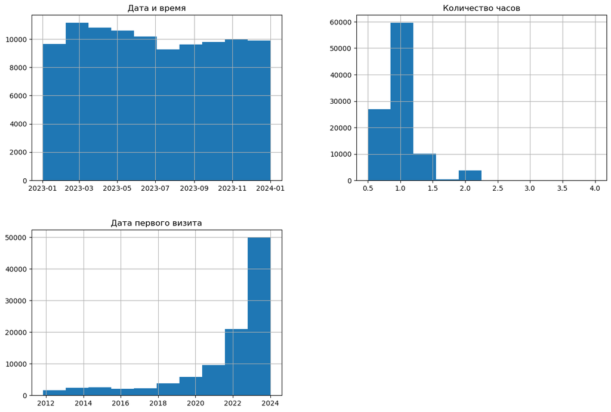

```python
df_filled[['Дата и время', 'Количество часов', 'Дата первого визита']].hist(figsize=(15,10));
```

**Замечание:** Гистограммы наглядно представляют как распределяются значения.

### Определим среднюю продолжительность услуг.

```python
average_duration = df_filled['Количество часов'].mean()
print(f"Средняя продолжительность услуг: {average_duration:.2f} часов")
```

```
Средняя продолжительность услуг: 0.97 часов
```

### Определим количество уникальных клиентов.

```python
unique_clients = df_filled['Клиент'].nunique()
print(f"Количество уникальных клиентов: {unique_clients}")
```

```
Количество уникальных клиентов: 64742
```

### Определим количество новых клиентов.

Новымы клиентами будем считать тех, для которых есть только одна запись в таблице и дата первого визита совпадает с датой текущего визита.

```python
visits = df_filled.groupby(['Клиент'])['id'].count().reset_index()
clients = visits[visits['id'] == 1]['Клиент'].to_list()
len(clients)
```

```
47897
```

**Замечание:** Нашлось 47897 клиентов с одной записью.

```python
len(df_filled[df_filled['Клиент'].isin(clients) & (df_filled['Дата и время'] == df_filled['Дата первого визита'])]['Клиент'])
```

```
21125
```

**Замечание:** Количество новых клиентов: 21125

### Определите среднюю частоту и продолжительность визита.

```python
average_frequency = df_filled.groupby('Клиент')['id'].count().mean()
print(f"Средняя частота визитов: {average_frequency:.2f} визитов на клиента")

average_duration_per_visit = df_filled.groupby('Клиент')['Количество часов'].mean().mean()
print(f"Средняя продолжительность визита c группировкой по клиентам: {average_duration_per_visit:.2f} часов")
```

```
Средняя частота визитов: 1.56 визитов на клиента
Средняя продолжительность визита c группировкой по клиентам: 0.98 часов
```

## Визуализация.

Построим графики этих показателей по месяцам.

```python
# Создание колонки месяца по годам
df_filled['Месяц'] = df['Дата и время'].dt.to_period('M')
```

### Средняя продолжительность услуг по месяцам.

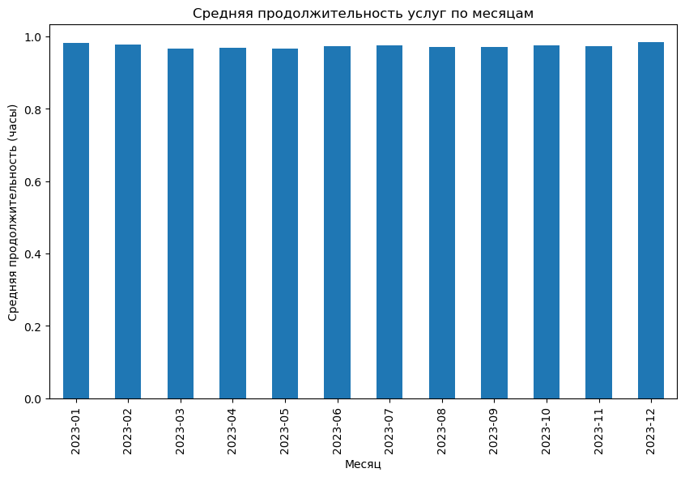

```python
# Группировка данных
monthly_avg_duration = df_filled.groupby('Месяц')['Количество часов'].mean()

# Построение графика
plt.figure(figsize=(10, 6))
monthly_avg_duration.plot(kind='bar')
plt.title('Средняя продолжительность услуг по месяцам')
plt.xlabel('Месяц')
plt.ylabel('Средняя продолжительность (часы)')
plt.show()
```

### Количество уникальных клиентов по месяцам.

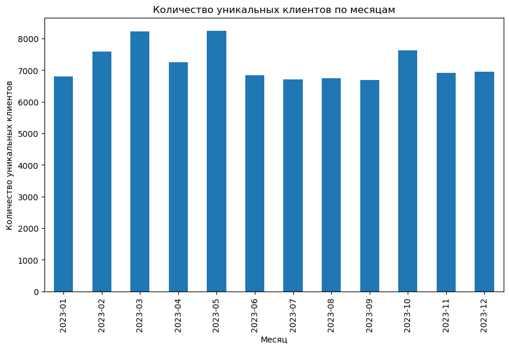

```python
# Группировка данных
monthly_unique_clients = df_filled.groupby('Месяц')['Клиент'].nunique()

# Построение графика
plt.figure(figsize=(10, 6))
monthly_unique_clients.plot(kind='bar')
plt.title('Количество уникальных клиентов по месяцам')
plt.xlabel('Месяц')
plt.ylabel('Количество уникальных клиентов')
plt.show()
```

### Количество новых клиентов по месяцам.

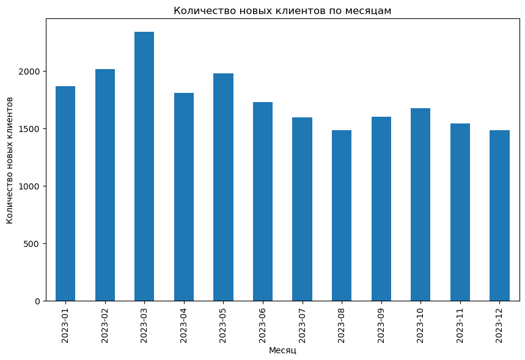

```python
# Поиск клиенты с одной записью
visits = df_filled.groupby(['Клиент'])['id'].count().reset_index()
clients = visits[visits['id'] == 1]['Клиент'].to_list()

# Получение таблицы с новыми клиентами
new_clients = df_filled[df_filled['Клиент'].isin(clients)
                       & (df_filled['Дата и время'] == df_filled['Дата первого визита'])]

# Группировка данных
new_clients_monthly = new_clients.groupby('Месяц')['Клиент'].nunique()

# Построение графика
plt.figure(figsize=(10, 6))
new_clients_monthly.plot(kind='bar')
plt.title('Количество новых клиентов по месяцам')
plt.xlabel('Месяц')
plt.ylabel('Количество новых клиентов')
plt.show()
```

### Cредняя частота и продолжительность визитов по месяцам.

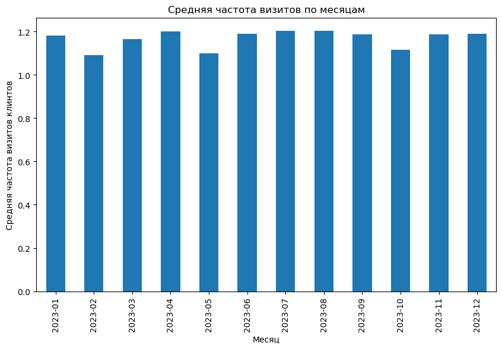

```python
# Группировка данных
monthly_clients_frequency = df_filled.groupby(['Месяц','Клиент'])['id'].count()
average_monthly_frequency = monthly_clients_frequency.reset_index().groupby('Месяц')['id'].mean()

# Построение графика
plt.figure(figsize=(10, 6))
average_monthly_frequency.plot(kind='bar')
plt.title('Средняя частота визитов по месяцам')
plt.xlabel('Месяц')
plt.ylabel('Средняя частота визитов клинтов')
plt.show()
```

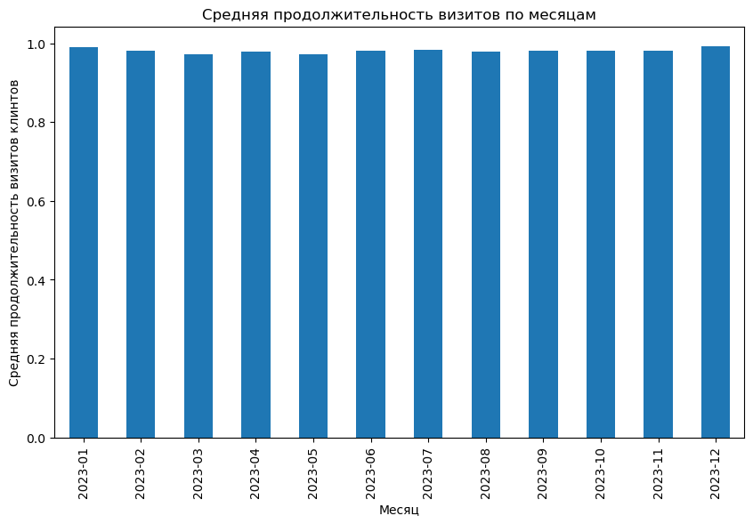

```python
# Группировка данных
monthly_clients_duration_per_visit = df_filled.groupby(['Месяц','Клиент'])['Количество часов'].mean()
average_monthly_duration_per_visit = (monthly_clients_duration_per_visit
                                      .reset_index()
                                      .groupby('Месяц')['Количество часов'].mean())

# Построение графика
plt.figure(figsize=(10, 6))
average_monthly_duration_per_visit.plot(kind='bar')
plt.title('Средняя продолжительность визитов по месяцам')
plt.xlabel('Месяц')
plt.ylabel('Средняя продолжительность визитов клинтов')
plt.show()
```

## Интерпретация.

**Средняя продолжительность услуг:**

Средняя продолжительность услуг составляет около `1 часа`. Этот показатель стабилен из месяца в месяц.  
Это может указывать на то, что большинство услуг в спа-салоне рассчитаны на короткое время, что может быть полезно для планирования расписания.

**Количество уникальных клиентов:**

В датасете присутствует значительное количество уникальных клиентов (`64742`), что говорит о широкой клиентской базе. В `марте` и в `мае` заметен небольшой всплеск.  
Это может быть полезно для анализа лояльности клиентов и их повторных визитов.

**Количество новых клиентов:**

Количество новых клиентов варьируется по месяцам, что может быть связано с сезонностью или маркетинговыми акциями. Анализ этого показателя поможет лучше планировать рекламные кампании. Заметен также тренд на снижение этого показателя к концу года.

*Эти выводы могут быть полезны для улучшения бизнес-процессов, планирования маркетинговых стратегий и повышения удовлетворенности клиентов.*